# An implementation of TDA in classifying and clustering time series data

By Hua-Wei Huang, 2020

This notebook contains step-to-step codes in performing TDA in classifying and clustering time series data. The background theories are illustrated [here](https://github.com/wawei225/TDA-Project/blob/main/TDA_report.pdf), this notebook includes only major codes. Our analysis highly depends on the library "giotto-tda" which is developed by Tauzin et al. (2020).

We organise this notebook in the following sections.

1. Data pre-processing
2. Constructing point cloud
3. Vietoris-Rips and persistent diagram
4. Features from persistent diagram  
   4.1.Bottleneck distance  
   4.2.Persistence image
5. Clustering (Agglomerative hierarchical clustering)  
   5.1.Bottleneck distance  
   5.2.Euclidean distance on original data  
   5.3.Euclidean distance on persistence image
6. Classification (1NN classifier)  
   6.1.Bottleneck distance  
   6.2.Euclidean distance on original data  
   6.3.Euclidean distance on persistence image
7. Validation index  
   7.1.Clustering: Adjusted Rand Index  
   7.2.Classification: Accuracy
8. Visual illustration of clustering and classificaiton results with UMAP

### Import data

```python
import pandas as pd
import numpy as np
```

```python
# read train and test dataset
df_train = pd.read_csv('C:/Users/hwhua/Desktop/personal_webpage/projects/TDA/data/DistalPhalanxOutlineAgeGroup_TRAIN.tsv', sep = '\t', header = None)
df_test = pd.read_csv('C:/Users/hwhua/Desktop/personal_webpage/projects/TDA/data/DistalPhalanxOutlineAgeGroup_TEST.tsv', sep = '\t', header = None)
```

```python
# seperated label and data
df_train_data = df_train.loc[:, 1:]
df_test_data = df_test.loc[:, 1:]

df_train_label = df_train.loc[:, 0]
df_test_label = df_test.loc[:, 0]

# combine train and test dataset for clustering
df_combined = df_train.append(df_test)
```

```python
# seperate label and data
df_combined_data = df_combined.loc[:,1:]
df_combined_label = df_combined.loc[:,0]
```

### 1. Data pre-processing

```python
# Z-normalisation

def znorm(time_series):
    for i in range(len(time_series)):

        temp_mean = np.mean(time_series[i])
        temp_std = np.std(time_series[i])

        temp_znorm = (time_series[i] - temp_mean)/ temp_std

        time_series[i] = temp_znorm


    return(time_series)
```

```python
df_train_data = df_train_data.to_numpy()
df_test_data = df_test_data.to_numpy()
df_combined_data = df_combined_data.to_numpy()

# z norm time series
final_df_train_data = znorm(df_train_data)
final_df_test_data = znorm(df_test_data)
final_df_combined_data = znorm(df_combined_data)
```

### 2. Constructing point cloud (Takens embedding)

```python
from gtda.time_series import SlidingWindow, SingleTakensEmbedding, TakensEmbedding, takens_embedding_optimal_parameters
from gtda.pipeline import Pipeline
from gtda.homology import VietorisRipsPersistence
from gtda.diagrams import Amplitude, PairwiseDistance, Scaler, Filtering, PersistenceEntropy
```

```python
STE = SingleTakensEmbedding(parameters_type='search', dimension=3,
                            time_delay=12, n_jobs=-1)
```

```python
# a point cloud is created for each row of time series, then the point clouds are combined in a list

combined_embedded = [0]*len(final_df_combined_data)

for i in range(len(final_df_combined_data)):
    temp_embedded = STE.fit_transform(final_df_combined_data[i])
    combined_embedded[i] = temp_embedded
```

### 3. Vietoris-Rips and persistent diagram

```python
homology_dimensions = (0, 1, 2)
VR = VietorisRipsPersistence(metric="euclidean", max_edge_length=10, homology_dimensions=homology_dimensions)
```

```python
combined_VR = VR.fit_transform(combined_embedded)
```

```python
# persistence diagram plot for the 5th time series
VR.plot(combined_VR, sample=5)
```

[interactive chart not shown]

### 4. Features from persistent diagram

#### 4.1. Bottleneck distance

```python
BT = PairwiseDistance(metric = 'bottleneck')
combined_distance_matrix =  BT.fit_transform(combined_VR)
```

#### 4.2. Persistence image

```python
from gtda.diagrams import PersistenceImage

PI = PersistenceImage()
combined_PI = PI.fit_transform(combined_VR)
```

```python
# select homology dimension = 0 and flattern matrix
zero_dim_PI = combined_PI[:,0,:,:]

combined_PI_data = np.zeros(shape=(539,10000))

# vectorise matrix of persistence image to an array
for i in range(len(zero_dim_PI)):
    temp_flatten = np.array(zero_dim_PI[i]).flatten()
    combined_PI_data[i] = temp_flatten
```

### 5. Clustering (Agglomerative hierarchical clustering)

#### 5.1. Bottleneck distance

```python
from sklearn.cluster import AgglomerativeClustering
```

```python
AHC = AgglomerativeClustering(affinity = 'precomputed', n_clusters = 3, linkage = 'average')
AHC_clusters = AHC.fit(combined_distance_matrix)
```

```python
true_label = df_combined_label.to_numpy()
pred_label = AHC_clusters.labels_
```

#### 5.2. Euclidean distance on original data

```python
AHC_ED = AgglomerativeClustering(affinity = 'euclidean', n_clusters = 3, linkage = 'average')
AHC_ED_clusters = AHC_ED.fit(final_df_combined_data)

# pred label
pred_label_ED = AHC_ED_clusters.labels_
```

#### 5.3. Euclidean distance on persistence Image

```python
AHC_PI_ED_clusters = AHC_ED.fit(combined_PI_data)
pred_label_PI_ED = AHC_ED_clusters.labels_
```

### 6. Classification (1NN classifier)

```python
# split train and test data/distance matrix based on original datasets

# BT
train_BT =  combined_distance_matrix[0:400,0:400]
test_to_train_BT = combined_distance_matrix[400:, 0:400]

# persistence image data

train_PI_data = combined_PI_data[0:400]
test_PI_data = combined_PI_data[400:]
```

#### 6.1. Bottleneck distance

```python
from sklearn.neighbors import KNeighborsClassifier

knn = KNeighborsClassifier(n_neighbors = 1, metric = 'precomputed')
knn.fit(train_BT, df_train_label)
knn_pred_label = knn.predict(test_to_train_BT)
```

#### 6.2. Euclidean distance on original data

```python
knn_ED = KNeighborsClassifier(n_neighbors = 1, metric = 'euclidean')
knn_ED.fit(final_df_train_data, df_train_label)
knn_ED_pred_label = knn_ED.predict(final_df_test_data)
```

#### 6.3. Euclidean distance on persistence image

```python
knn_PI_fit = knn_ED.fit(train_PI_data, df_train_label)
knn_PI_ED_pred_label = knn_PI_fit.predict(test_PI_data)
```

### 7. Validation index

#### 7.1. Clustering: Adjusted Rand Index

```python
from sklearn.metrics import adjusted_rand_score, accuracy_score
# bottleneck
BT_ARI = adjusted_rand_score(true_label, pred_label)

# original data
Raw_ARI = adjusted_rand_score(true_label, pred_label_ED)

# persistence image
PI_ARI = adjusted_rand_score(true_label, pred_label_PI_ED)


print('Bottleneck: {0} \nOriginal data: {1} \nPersistence image: {2}'.format(BT_ARI, Raw_ARI, PI_ARI))
```

```
Bottleneck: 0.2279587722110208
Original data: 0.030990487948089878
Persistence image: 0.23923265992409148
```

#### 7.2. Classification: Accuracy

```python
BT_Accuracy = accuracy_score(df_test_label, knn_pred_label)
Raw_Accuracy = accuracy_score(df_test_label, knn_ED_pred_label)
PI_Accuracy = accuracy_score(df_test_label, knn_PI_ED_pred_label)

print('Bottleneck: {0} \nOriginal data: {1} \nPersistence image: {2}'.format(BT_Accuracy, Raw_Accuracy, PI_Accuracy))
```

```
Bottleneck: 0.6330935251798561
Original data: 0.6258992805755396
Persistence image: 0.6402877697841727
```

### 8. Visual illustration

We present results of clustering on whole datasets and results of classification on test dataset with UMAP for visualisation in two-dimension.

```python
import umap
import umap.plot
```

```python
import matplotlib.pyplot
```

```python
mapper = umap.UMAP().fit(final_df_combined_data)
```

#### Clustering: original label (true label)

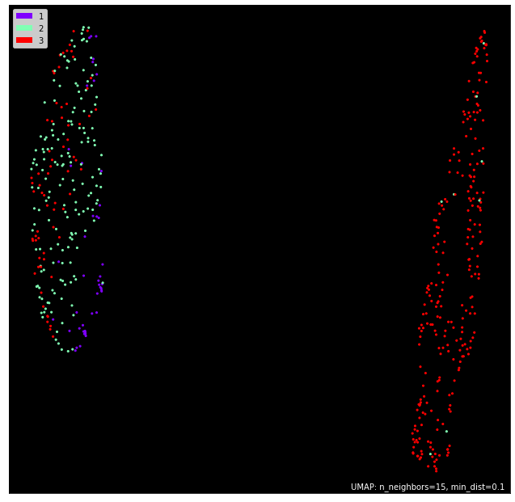

```python
umap.plot.points(mapper, labels=df_combined_label, theme='fire')
```

#### Clustering: Predicted label from Bottleneck distance

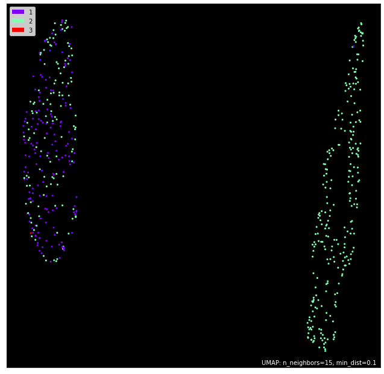

```python
umap.plot.points(mapper, labels=pred_label+1, theme='fire')
```

#### Clustering: Predicted label from Euclidean distance

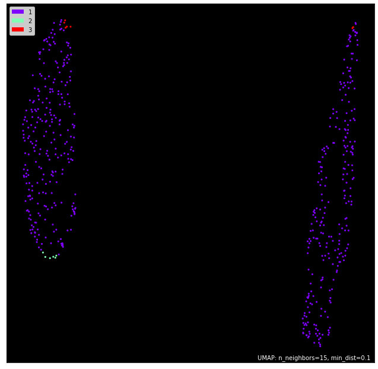

```python
umap.plot.points(mapper, labels=pred_label_ED+1, theme='fire')
```

#### Clustering: Predicted label from Euclidean distance on Persistence image

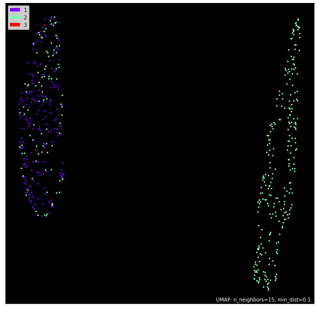

```python
umap.plot.points(mapper, labels=pred_label_PI_ED+1, theme='fire')
```

```python
mapper_class = umap.UMAP().fit(final_df_test_data)
```

#### Classification: Original label (true label on test dataset)

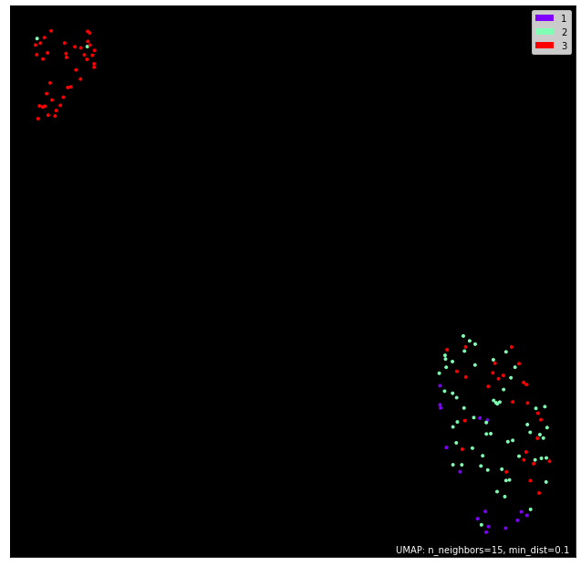

```python
umap.plot.points(mapper_class, labels=df_test_label, theme='fire')
```

#### Classification: Predicted label from Bottleneck distance

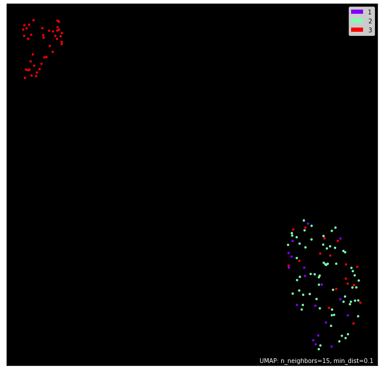

```python
umap.plot.points(mapper_class, labels=knn_pred_label, theme='fire')
```

#### Classification: Predicted label from Euclidean distance

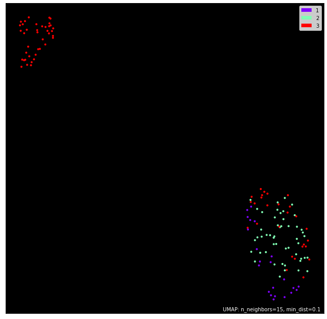

```python
umap.plot.points(mapper_class, labels=knn_ED_pred_label, theme='fire')
```

#### Classification: Predicted label from Euclidean distance on Persistence image

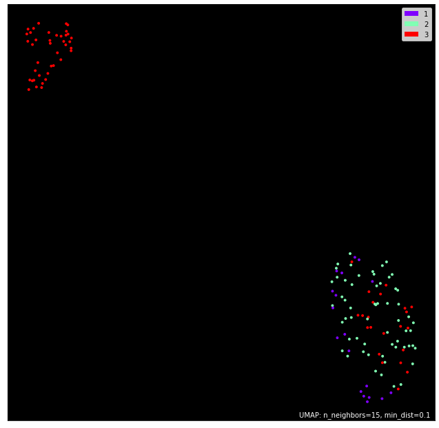

```python
umap.plot.points(mapper_class, labels=knn_PI_ED_pred_label, theme='fire')
```

### Reference

Tauzin, G., Lupo, U., Tunstall, L., Pérez, J.B., Caorsi, M., Medina-Mardones, A., Dassatti, A. and Hess, K., 2020. giotto-tda: A Topological Data Analysis Toolkit for Machine Learning and Data Exploration. arXiv preprint arXiv:2004.02551.